# Beta_Distribution_Elting

Rosalee Elting

2023-02-06

# 1 Definition

The beta distribution is used for modeling continuous variables that can be expressed as a proportion. Therefore, it takes values from 0 to 1. The data must be bounded between 0 and 1 and this distribution does not take negative values. the beta distribution is often used as a conjugate prior probability in Bayes for the following distributions: binomial, negative binomial, geometric and Bernoulli. This distribution is highly helpful for modeling the stochastic effects of random variables as a proportion. It is further helpful when plotting proportions that are binomial or have skew.

## 1.1 Parameters

The beta distribution takes two parameters The parameters of a beta distribution are both continuous and positive. These parameters are denoted as: $\alpha ,\beta$

# 2 Plot

Here I plot some different values for $\alpha$ $\beta$ and will plot them below (titled by scenario in table)

[output not shown]

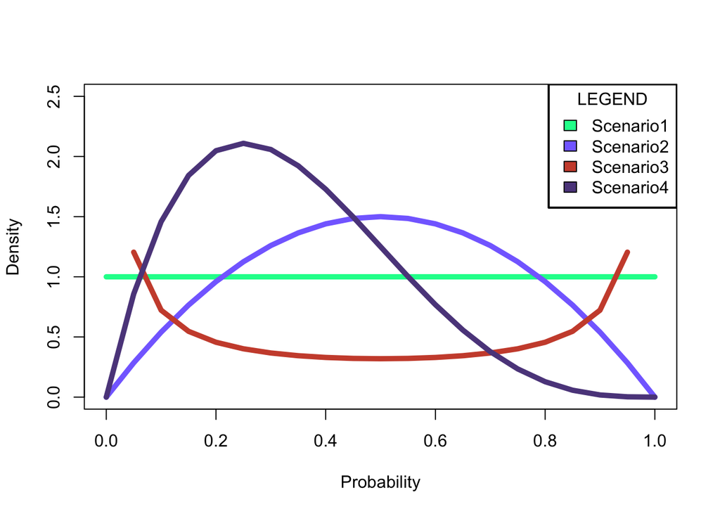

```r
x <- seq(from =0, to =1, by =0.05)
plot(x, dbeta(x, 1, 1), col = "mediumspringgreen", type = "l", ylab = "Density", xlab = "Probability", ylim = c(0,2.5), lwd =5)
lines(x, dbeta(x, 2,2), col = "lightslateblue", lwd =5)
lines(x, dbeta(x, 0.2, 0.2), col = "tomato3", lwd=5)
lines(x, dbeta(x, 2,4), col = "mediumpurple4", lwd=5)


legend("topright",
       box.lwd = 2 , title="LEGEND",
       legend=c("Scenario1", "Scenario2","Scenario3" , "Scenario4"),
       fill = c("mediumspringgreen","lightslateblue", "tomato3", "mediumpurple4"))
```

# 3 Mathematical Definition

The mathematical definition for the probability function is:
$$[y | \theta] = \frac{1-y
^{\beta-1}y^{\alpha-1}}{B(\alpha, \beta)}$$

## 3.1 Moment Matching

To match moments, the following relationships can be used:
**Mean from $\alpha$ and $\beta$ :**
$$\mu = \frac{\alpha}{\alpha+\beta}$$
**Variance, $\sigma$, from $\alpha$ and $\beta$:**
$$\sigma^2 =
\frac{\alpha\beta}{(\alpha+\beta)^2(\alpha+\beta+1)}$$
**$\alpha$ from mean and variance:**
$$\alpha =
\mu(\frac{\mu(1-\mu)}{\sigma^2} - 1)$$

**$\beta$ from mean and variance:**
$$\beta =
(1-\mu)(\frac{\mu(1-\mu)}{\sigma^2}-1)$$

# 4 Use in Ecology

Beyond its use as a prior for Bayes, other uses for Beta distributions include:

Decay

Survival

probability of transitioning from one state to another *(e.g., plants changing life stages)*

Plant cover as it is often skewed or has greatest densities at high and low probabilities

Population trait distributions

# 5 References

**Hobbs, N.T. and Hooten, M.B.** 2015. Bayesian Models: A Statistical Primer for Ecologists.Princetom Unviersity Press, Princeton, NJ.  
**Gotelli, N.** 2021. Video: https://ngotelli.github.io/Bio381Vids/  
**Damgaard, C.F. and Irvine, K.M.** 2019. Using the beta distribution to analyze plant cover data. *Journal of Ecology* 107: 2747-259. DOI: 10.1111/1365-2745.13200.  
**Klauschies, T., Coutinho, R.M., and Gaedke, U.,** 2018. A beta distribution-based moment closure enhances the reliability of trait-based aggregate models for natural populations and communities. *Ecological Modelling* 381:46-77. DOI: 10.1016/j.ecolmodel.2018.02.001